# GENERADOR DE IMÁGENES: Figuras Geométricas Aleatorias

## Concepto

Este notebook implementa un generador de imágenes que crea composiciones artísticas con figuras geométricas aleatorias. Cada imagen es única y generada proceduralmente.

**Características:**

**Formato de imagen:** PNG (Portable Network Graphics)

- **Ventajas:** Sin pérdida de calidad, transparencia, compresión sin artefactos
- **Resolución:** 800x600 píxeles (personalizable)
- **Profundidad de color:** 24 bits (16.7 millones de colores)

**Aplicaciones:**

- Arte generativo
- Fondos de pantalla únicos
- Material para pruebas de visión por computadora
- Inspiración para diseño gráfico

```python
import random
import os
import matplotlib.pyplot as plt
from datetime import datetime
import numpy as np
from PIL import Image, ImageDraw
```

## Librerías utilizadas

### 1. **PIL/Pillow** (Python Imaging Library)

- **Propósito**: Creación y manipulación de imágenes
- **Componentes principales**:
  - `Image`: Clase principal para trabajar con imágenes
  - `ImageDraw`: Dibuja figuras geométricas sobre imágenes
- **Instalación**: `pip install Pillow`

### 2. **matplotlib.pyplot**

- **Propósito**: Visualizar imágenes directamente en el notebook
- **Uso**: Mostrar las imágenes generadas sin guardarlas
- **Ventaja**: Permite ver resultados inmediatos
- **Instalación**: `pip install matplotlib`

### 3. **numpy**

- **Propósito**: Manipulación numérica de matrices de píxeles
- **Uso**: Para efectos avanzados como degradados
- **Ventaja**: Operaciones matemáticas eficientes
- **Instalación**: `pip install numpy`

### 4. **random** (estándar)

- **Propósito**: Generar valores aleatorios para colores, posiciones, etc.
- **Uso**: Cada imagen es única

### 5. **os** (estándar)

- **Propósito**: Crear carpetas y manejar archivos
- **Uso**: Organizar las imágenes generadas

### 6. **datetime** (estándar)

- **Propósito**: Timestamps para nombres de archivo únicos

```python
class GeneradorImagenes:
    """
    Clase para generar imágenes artísticas con figuras geométricas
    """

    def __init__(self, ancho=800, alto=600):
        """
        Inicializa el generador con dimensiones personalizables

        Args:
            ancho (int): Ancho de la imagen en píxeles
            alto (int): Alto de la imagen en píxeles
        """
        self.ancho = ancho
        self.alto = alto
        self.colores_fondo = self._generar_paleta_fondos()

    def _generar_paleta_fondos(self):
        """
        Genera una paleta de colores de fondo (método interno)
        """
        return [
            (255, 255, 255),
            (240, 248, 255),
            (245, 245, 220),
            (230, 230, 250),
            (255, 228, 225),
            (240, 255, 240),
            (255, 250, 205),
        ]

    def generar_color_aleatorio(self, brillo_min=0, brillo_max=255):
        """
        Genera un color RGB aleatorio

        Args:
            brillo_min (int): Valor mínimo para cada componente (0-255)
            brillo_max (int): Valor máximo para cada componente (0-255)

        Returns:
            tuple: (R, G, B) valores de color
        """
        return (
            random.randint(brillo_min, brillo_max),
            random.randint(brillo_min, brillo_max),
            random.randint(brillo_min, brillo_max)
        )

    def crear_imagen_vacia(self, color_fondo=None):
        """
        Crea una imagen nueva con el fondo especificado

        Args:
            color_fondo (tuple): Color RGB para el fondo

        Returns:
            PIL.Image: Nueva imagen
        """
        if color_fondo is None:
            color_fondo = random.choice(self.colores_fondo)

        # Crear imagen RGB
        imagen = Image.new('RGB', (self.ancho, self.alto), color_fondo)
        return imagen

    def dibujar_rectangulo(self, dibujo):
        """
        Dibuja un rectángulo aleatorio

        Args:
            dibujo (ImageDraw): Objeto para dibujar
        """
        # Coordenadas aleatorias
        x1 = random.randint(50, self.ancho - 150)
        y1 = random.randint(50, self.alto - 150)
        x2 = x1 + random.randint(50, 200)
        y2 = y1 + random.randint(50, 200)

        # Color aleatorio
        color = self.generar_color_aleatorio()

        # Borde aleatorio (0 = sin borde, 1-5 = con borde)
        if random.random() > 0.3:  # 70% con borde
            dibujo.rectangle([x1, y1, x2, y2],
                           fill=color,
                           outline=(0, 0, 0),
                           width=random.randint(1, 5))
        else:
            dibujo.rectangle([x1, y1, x2, y2], fill=color)

    def dibujar_elipse(self, dibujo):
        """
        Dibuja una elipse aleatoria
        """
        x1 = random.randint(50, self.ancho - 150)
        y1 = random.randint(50, self.alto - 150)
        x2 = x1 + random.randint(50, 200)
        y2 = y1 + random.randint(50, 200)

        color = self.generar_color_aleatorio()

        if random.random() > 0.3:
            dibujo.ellipse([x1, y1, x2, y2],
                          fill=color,
                          outline=(0, 0, 0),
                          width=random.randint(1, 5))
        else:
            dibujo.ellipse([x1, y1, x2, y2], fill=color)

    def dibujar_linea(self, dibujo):
        """
        Dibuja una línea aleatoria
        """
        x1 = random.randint(10, self.ancho - 10)
        y1 = random.randint(10, self.alto - 10)
        x2 = random.randint(10, self.ancho - 10)
        y2 = random.randint(10, self.alto - 10)

        color = self.generar_color_aleatorio()
        ancho_linea = random.randint(1, 10)

        dibujo.line([x1, y1, x2, y2], fill=color, width=ancho_linea)

    def dibujar_poligono(self, dibujo):
        """
        Dibuja un polígono aleatorio (triángulo o cuadrilátero)
        """
        num_puntos = random.choice([3, 4])  # Triángulo o cuadrilátero
        puntos = []

        centro_x = random.randint(200, self.ancho - 200)
        centro_y = random.randint(200, self.alto - 200)
        radio = random.randint(50, 150)

        # Generar puntos alrededor de un centro
        for i in range(num_puntos):
            angulo = (2 * 3.14159 * i / num_puntos) + random.uniform(-0.2, 0.2)
            x = centro_x + radio * np.cos(angulo)
            y = centro_y + radio * np.sin(angulo)
            puntos.append((x, y))

        color = self.generar_color_aleatorio()

        if random.random() > 0.3:
            dibujo.polygon(puntos, fill=color, outline=(0, 0, 0), width=2)
        else:
            dibujo.polygon(puntos, fill=color)

    def generar_imagen_aleatoria(self, num_figuras=None):
        """
        Genera una imagen completa con figuras aleatorias

        Args:
            num_figuras (int): Número de figuras a dibujar

        Returns:
            PIL.Image: Imagen generada
        """
        imagen = self.crear_imagen_vacia()
        dibujo = ImageDraw.Draw(imagen)

        if num_figuras is None:
            num_figuras = random.randint(5, 15)

        funciones_dibujo = {
            'rectangulo': self.dibujar_rectangulo,
            'elipse': self.dibujar_elipse,
            'linea': self.dibujar_linea,
            'poligono': self.dibujar_poligono
        }

        for _ in range(num_figuras):
            tipo_figura = random.choice(list(funciones_dibujo.keys()))
            funciones_dibujo[tipo_figura](dibujo)

        return imagen

    def generar_con_efectos(self, efecto='normal'):
        """
        Genera imagen con efectos especiales

        Args:
            efecto (str): Tipo de efecto ('normal', 'degradado', 'mosaico')
        """
        if efecto == 'normal':
            return self.generar_imagen_aleatoria()

        elif efecto == 'degradado':
            imagen = Image.new('RGB', (self.ancho, self.alto))
            dibujo = ImageDraw.Draw(imagen)

            for y in range(self.alto):
                r = int(255 * y / self.alto)
                g = int(255 * (1 - y / self.alto))
                b = int(255 * (0.5 + 0.5 * y / self.alto))
                for x in range(0, self.ancho, 10):
                    dibujo.rectangle([x, y, x+10, y+1], fill=(r, g, b))

            dibujo = ImageDraw.Draw(imagen)
            for _ in range(5):
                self.dibujar_elipse(dibujo)

            return imagen

        elif efecto == 'mosaico':
            imagen = Image.new('RGB', (self.ancho, self.alto))
            dibujo = ImageDraw.Draw(imagen)

            tamaño_celda = 40
            for x in range(0, self.ancho, tamaño_celda):
                for y in range(0, self.alto, tamaño_celda):
                    color = self.generar_color_aleatorio()
                    dibujo.rectangle([x, y, x+tamaño_celda-2, y+tamaño_celda-2],
                                   fill=color)

            return imagen
```

```python
# ============================================
# FUNCIONES PARA VISUALIZAR EN NOTEBOOK
# ============================================

def mostrar_imagen(imagen, titulo="Imagen Generada"):
    """
    Muestra una imagen en el notebook usando matplotlib

    Args:
        imagen (PIL.Image): Imagen a mostrar
        titulo (str): Título para la imagen
    """
    plt.figure(figsize=(10, 8))
    plt.imshow(imagen)
    plt.title(titulo, fontsize=16, fontweight='bold')
    plt.axis('off')
    plt.tight_layout()
    plt.show()

def mostrar_galeria(imagenes, filas=2, columnas=3):
    """
    Muestra múltiples imágenes en una galería

    Args:
        imagenes (list): Lista de imágenes PIL
        filas (int): Número de filas
        columnas (int): Número de columnas
    """
    fig, axes = plt.subplots(filas, columnas, figsize=(15, 10))
    axes = axes.flatten()

    for i, ax in enumerate(axes):
        if i < len(imagenes):
            ax.imshow(imagenes[i])
            ax.set_title(f"Imagen {i+1}", fontsize=12)
            ax.axis('off')
        else:
            ax.axis('off')

    plt.suptitle("Galería de Imágenes Generadas", fontsize=16, fontweight='bold')
    plt.tight_layout()
    plt.show()

def guardar_imagen(imagen, nombre_base="imagen_generada"):
    """
    Guarda una imagen con timestamp

    Args:
        imagen (PIL.Image): Imagen a guardar
        nombre_base (str): Nombre base del archivo

    Returns:
        str: Ruta del archivo guardado
    """
    if not os.path.exists("imagenes_generadas"):
        os.makedirs("imagenes_generadas")

    timestamp = datetime.now().strftime("%Y%m%d_%H%M%S")
    nombre_archivo = f"imagenes_generadas/{nombre_base}_{timestamp}.png"

    # Guardar imagen
    imagen.save(nombre_archivo, "PNG")
    print(f"Imagen guardada: {nombre_archivo}")

    return nombre_archivo
```

```
DEMOSTRACIÓN DEL GENERADOR DE IMÁGENES
============================================================

1. Generando imagen aleatoria...
```

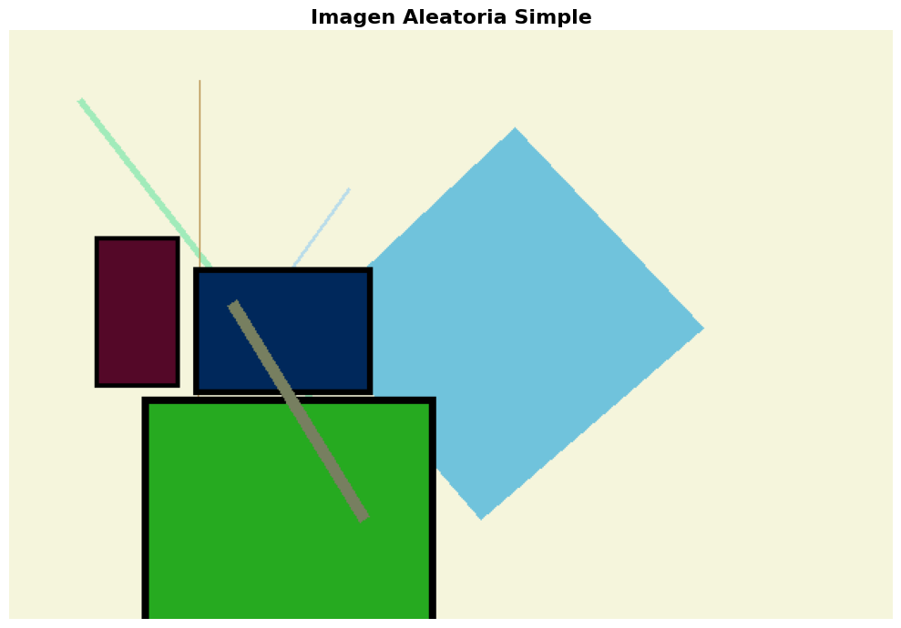

```
Características de la imagen:
   • Dimensiones: 600x400 píxeles
   • Formato: RGB (24 bits por píxel)
   • Figuras: 8 elementos aleatorios
   • Tamaño aproximado: 0.7 MB
```

```python
# ============================================
# DEMOSTRACIÓN 1: Generación básica
# ============================================

print("DEMOSTRACIÓN DEL GENERADOR DE IMÁGENES")
print("=" * 60)

# Crear instancia del generador
generador = GeneradorImagenes(ancho=600, alto=400)

# Generar una imagen simple
print("\n1. Generando imagen aleatoria...")
imagen1 = generador.generar_imagen_aleatoria(num_figuras=8)
mostrar_imagen(imagen1, "Imagen Aleatoria Simple")

# Explicación de la imagen
print("\nCaracterísticas de la imagen:")
print(f"   • Dimensiones: {generador.ancho}x{generador.alto} píxeles")
print(f"   • Formato: RGB (24 bits por píxel)")
print(f"   • Figuras: 8 elementos aleatorios")
print(f"   • Tamaño aproximado: {generador.ancho * generador.alto * 3 / 1024 / 1024:.1f} MB")
```

```
VARIACIONES DEL GENERADOR
============================================================

Imágenes con diferente número de figuras:
   Generando imagen con 5 figuras...
   Generando imagen con 10 figuras...
   Generando imagen con 15 figuras...
   Generando imagen con 20 figuras...
```

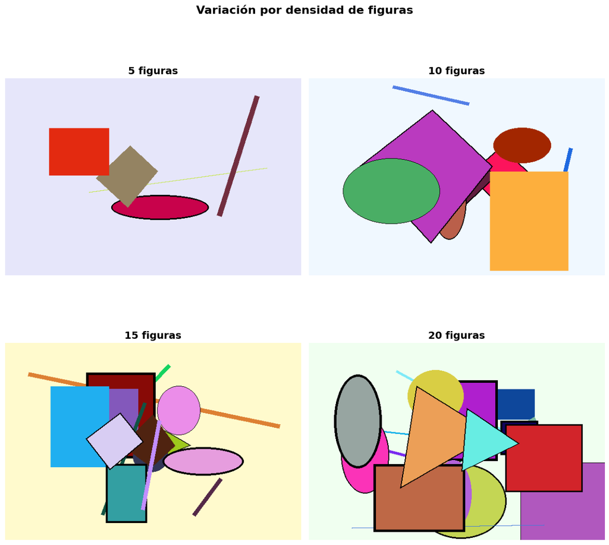

```python
# ============================================
# DEMOSTRACIÓN 2: Variaciones y estilos
# ============================================

print("VARIACIONES DEL GENERADOR")
print("=" * 60)

# Generar imágenes con diferentes densidades
print("\nImágenes con diferente número de figuras:")

figuras_variadas = []
cantidades = [5, 10, 15, 20]

for cant in (cantidades):
    print(f"   Generando imagen con {cant} figuras...")
    img = generador.generar_imagen_aleatoria(num_figuras=cant)
    figuras_variadas.append(img)

# Mostrar en cuadrícula
fig, axes = plt.subplots(2, 2, figsize=(12, 12))
axes = axes.flatten()

for (ax, img, cant) in (zip(axes, figuras_variadas, cantidades)):
    ax.imshow(img)
    ax.set_title(f"{cant} figuras", fontsize=14, fontweight='bold')
    ax.axis('off')

plt.suptitle("Variación por densidad de figuras", fontsize=16, fontweight='bold')
plt.tight_layout()
plt.show()
```

```
EFECTOS ESPECIALES
============================================================
   Generando efecto: normal
   Generando efecto: degradado
   Generando efecto: mosaico
```

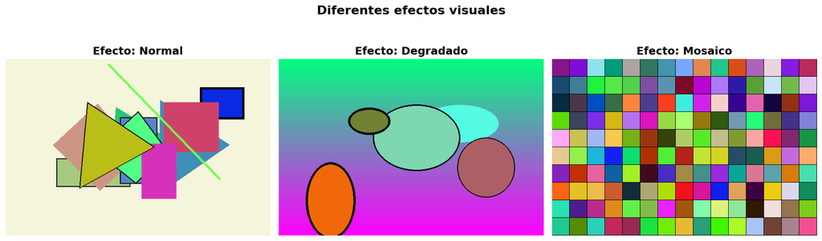

```python
# ============================================
# DEMOSTRACIÓN 3: Efectos especiales
# ============================================

print("EFECTOS ESPECIALES")
print("=" * 60)

# Generar diferentes efectos
efectos = ['normal', 'degradado', 'mosaico']
imagenes_efectos = []

for efecto in efectos:
    print(f"   Generando efecto: {efecto}")
    img = generador.generar_con_efectos(efecto)
    imagenes_efectos.append(img)

# Mostrar efectos
fig, axes = plt.subplots(1, 3, figsize=(15, 5))

for (ax, img, efecto) in (zip(axes, imagenes_efectos, efectos)):
    ax.imshow(img)
    ax.set_title(f"Efecto: {efecto.capitalize()}", fontsize=14, fontweight='bold')
    ax.axis('off')

plt.suptitle("Diferentes efectos visuales", fontsize=16, fontweight='bold')
plt.tight_layout()
plt.show()
```

```
GALERÍA DE IMÁGENES
============================================================
Generando 6 imágenes únicas...
   Imagen 1/6
   Imagen 2/6
   Imagen 3/6
   Imagen 4/6
   Imagen 5/6
   Imagen 6/6
```

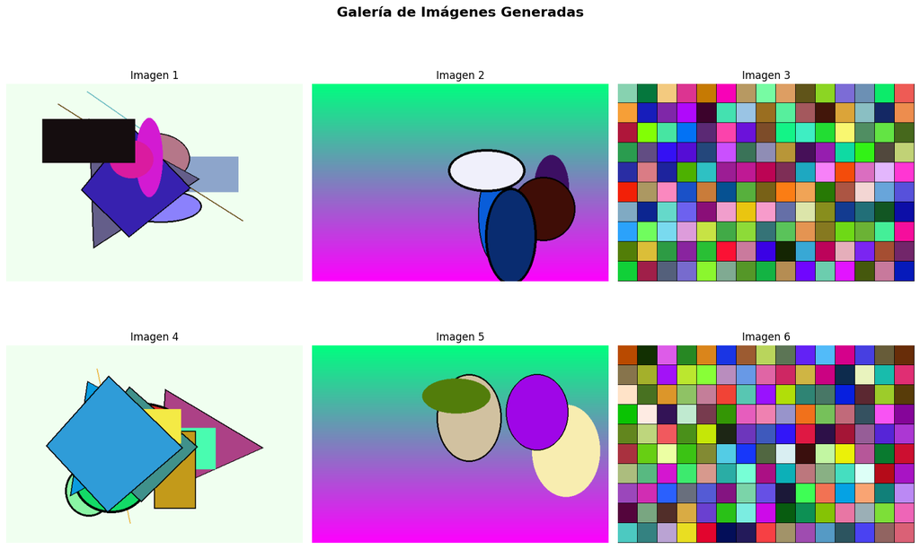

```
Guardando una imagen de ejemplo...
Imagen guardada: imagenes_generadas/galeria_ejemplo_20260224_080110.png
```

```
'imagenes_generadas/galeria_ejemplo_20260224_080110.png'
```

```python
# ============================================
# DEMOSTRACIÓN 4: Galería de imágenes
# ============================================

print("GALERÍA DE IMÁGENES")
print("=" * 60)


num_imagenes = 6
galeria = []

print(f"Generando {num_imagenes} imágenes únicas...")

for i in range(num_imagenes):
    print(f"   Imagen {i+1}/{num_imagenes}")

    if i % 3 == 0:
        img = generador.generar_imagen_aleatoria(num_figuras=12)
    elif i % 3 == 1:
        img = generador.generar_con_efectos('degradado')
    else:
        img = generador.generar_con_efectos('mosaico')

    galeria.append(img)

mostrar_galeria(galeria, filas=2, columnas=3)

print("\nGuardando una imagen de ejemplo...")
guardar_imagen(galeria[0], "galeria_ejemplo")
```